# PAA Virtual Workshop Series: Population & Environment Data

### Import pre-processed 10km PM2.5 data

Now let’s import and prepare the 10km gridded data set. Recall that the 10km data is in gridded, vector format. That means that the vector polygon geometries consist of the exact same 10km X 10km dimensions, arranged in a grid pattern. Similar to how ECHOLab estimates smoke-derived PM2.5 values for county and tract polygons, they do the same for the uniform 10km grid polygons. They also assign each grid polygon a unique grid identification code and include it in the RDS tabular data as a variable.

Again, we will reduce this data to just the dates and locations that we need for our study extent. Filtering out extraneous dates is straightforward. But, the 10km gridded data does not have any location identifiers that allow us to reduce the data to just Wisconsin using tabular data wrangling. We could read in the entire 10km grid data set, convert it to a sf R object, and and try to use it in its full size. But the data set is very large. More efficient way to do this - especially for scaling or in repeated processing - would be to reduce the 10km grid polygons to just those that cover the state of Wisconsin. To process the 10km gridded data to just those that cover the study timeframe and the stae of Wisconsin, we will take the following steps:

1. Import the full tabular data for smoke at the 10km grid level, and reduce to just the days present in our study period.

```r
# Load smokePM2.5 predictions on smoke days
  preds <- readRDS(echo_10km_path)
  str(preds)

# reduce raw data to years needed
  preds <- preds |>
    filter(date %within% interval(start_date, end_date))

# free memory
  gc()
```

2. Generate a shapefile for the boundary of Wisconsin using `tidyverse` conventions and `st_union()`.

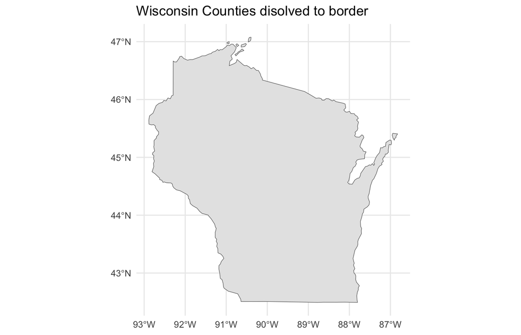

```r
# collapse WI counties to one border
  sf_wi <- sf_county_2010 |>
    mutate(state = "WI") |>
    group_by(state) |>
      summarise(geometry = st_union(geometry)) |>
    ungroup()

# confirm collapse
  ggplot() +
    geom_sf(data = sf_wi) +
    labs(title = "Wisconsin Counties disolved to border") +
    theme_minimal()
```

3. Import the shapefile for the 10km grid and format it with the `master_crs`.

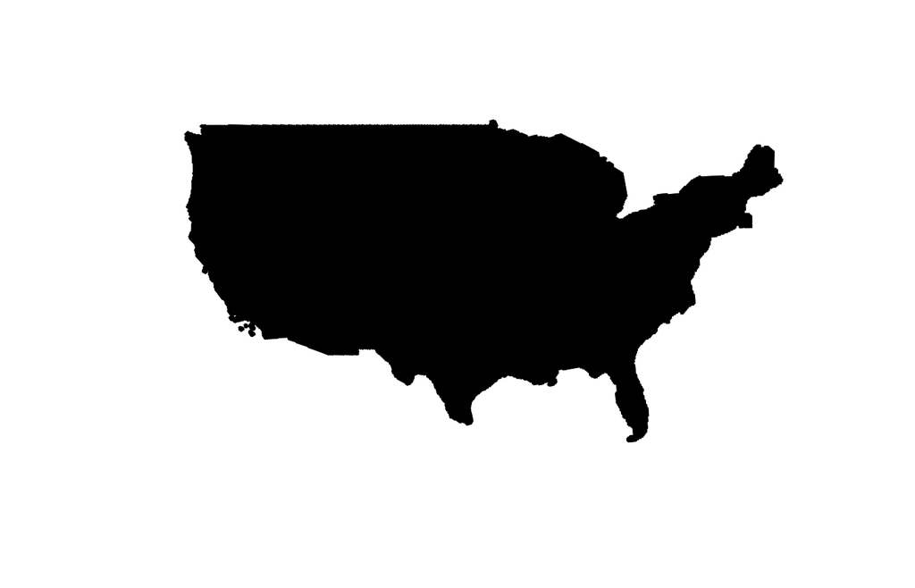

```r
# Load 10 km grid
  grid_10km = read_sf(echo_10km_grid)
  plot(grid_10km$geometry)
```

```r
# does 10km_grid have same CRS as master_crs?
  st_crs(grid_10km) == master_crs
```

```
## [1] FALSE
```

```r
# reproject to master_crs
  grid_10km <- st_transform(grid_10km, master_crs)
  st_crs(grid_10km) == master_crs
```

```
## [1] TRUE
```

4. Use `sf::st_intersection()` to reduce the full `grid_10km` shapefile to just grid polygons that are within or cross the boundary into Wisconsin.

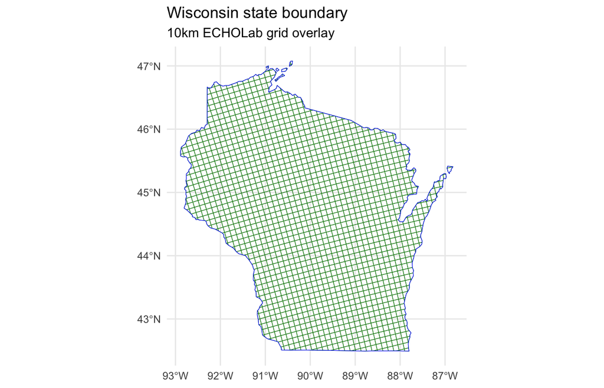

```r
# make a dataframe with just the grids that fall within or on the WI border
  sf_wi_10km <- st_intersection(grid_10km, sf_wi)

# plot to confirm
  ggplot() +
    geom_sf(data = sf_wi_10km,
            color = "forestgreen",
            fill = NA) +
    geom_sf(data = sf_wi,
            color = "blue",
            fill = NA) +
    labs(title = "Wisconsin state boundary",
         subtitle = "10km ECHOLab grid overlay") +
    theme_minimal()
```

```r
# remove full grid database
  rm(grid_10km,
     temp)
  gc()
```

```
##             used   (Mb) gc trigger   (Mb) limit (Mb)  max used   (Mb)
## Ncells   5888757  314.5   31314263 1672.4         NA  39142828 2090.5
## Vcells 171344194 1307.3  561827265 4286.5      24576 546446574 4169.1
```

5. Finally, we will take the tabular smoke prediction data and generate a comprehensive tabular data set of all dates/counties for the study extent, and perform some data wrangling.

```r
# Get full combination of grid cell-days
# Warning: this may require a large amount of memory if performing on multiple years and states
  days_by_10km = expand.grid(grid_id_10km = sf_wi_10km$ID, date = all_dates)

# Match smoke predictions on smoke days to grid cell-days
  smoke_10km = left_join(days_by_10km, preds, by = c("grid_id_10km", "date"))

# Predict 0 for remaining grid cell-days, which are non-smoke days
  smoke_10km = mutate(smoke_10km, smokePM_pred = replace_na(smokePM_pred, 0))

# generate helper variables for 10km grid
  smoke_10km <- smoke_10km |>
    arrange(grid_id_10km, date) |>
    mutate(year = year(date),
           prior_30 = (date - 30),
           prior_7 = (date - 7),
           window_30day = interval(start = prior_30, end = date),
           window_7day = interval(start = prior_7, end = date))

# clean up environment
  rm(days_by_10km,
     preds)
```

Use `View()` to check out the data structure of the county, tract, and 10km smoke data.

We now have daily smoke-derived PM2.5 to analyze at the county, tract, and 10km grid level in tabular form. The tract and county ECHOLab data can be easily integrated into any county and tract level data using standard FIPS geographic identifiers. The 10km tabular data will need to be converted to an `sf` R object using the `sf_wi_10km` shapefile before integrating with county, tract, and individual-level data.

# Part 5: Data Integration -

Recall that our ultimate goal is to associate the high-frequency air quality data with each record in the population data and the survey data. We have completed the steps to format the ECHOLab data to easily merge with census data and survey data. Let’s explore some use cases and different ways to integrate the ECHOLab data.

## Use Case #1: County-level Annual Average PM2.5

Note that the county ECHOLab data have GEOID fields. We can easily merge them to our county ACS data without using any GIS processing. Before merging, we can do any necessary data wrangling to the `smoke_county` data set. To compute a county-level annual average, we will complete the following steps:

1. Wrangle the ECHOLab tabular data to generate the necessary helper variables and summary measures, like averages.
2. `left_join()` the summary measures to the ACS time series population data using date and FIPS variables.
3. `right_join()` county geometries to the tabular ACS data and generate some simple maps as a sanity check.

```r
# Use Case #1 - Annual average, county level ----
# -- Data wrangling ----
# generate helper variables
  smoke_county <- smoke_county |>
    arrange(GEOID, date) |>
    mutate(year = year(date),
           prior_30 = (date - 30),
           prior_7 = (date - 7),
           window_30day = interval(start = prior_30, end = date),
           window_7day = interval(start = prior_7, end = date))

# make annual PM2.5 average
  county_annual_avg <- smoke_county |>
    group_by(GEOID, year) |>
      arrange(date) |>
      mutate(annual_pm25_average = mean(smokePM_pred, na.rm = TRUE),
             annual_pm25_max = max(smokePM_pred, na.rm = TRUE)) |>
    ungroup()

# reduce to 1 column per year
  county_annual_avg <- county_annual_avg |>
    dplyr::select(GEOID, year, annual_pm25_average, annual_pm25_max) |>
    distinct()

# stack ACS timeseries data
  county_pop_data <- bind_rows(acs_county)
  str(county_pop_data)
```

```
## tibble [720 × 8] (S3: tbl_df/tbl/data.frame)
##  $ GEOID         : chr [1:720] "55001" "55003" "55005" "55007" ...
##  $ county_fips   : chr [1:720] "55001" "55003" "55005" "55007" ...
##  $ geog_level    : chr [1:720] "county" "county" "county" "county" ...
##  $ year          : int [1:720] 2014 2014 2014 2014 2014 2014 2014 2014 2014 2014 ...
##  $ tot_pop       : num [1:720] 20604 16065 45718 15064 252698 ...
##  $ pov_status    : num [1:720] 2446 2618 6002 1914 28682 ...
##  $ med_hh_income : num [1:720] 45366 39172 44709 45158 53254 ...
##  $ med_gross_rent: num [1:720] 718 588 642 563 708 638 645 678 710 585 ...
```

```r
# merge to county by year and GEOID
  county_pop_data <- left_join(county_pop_data, county_annual_avg, by = c("GEOID", "year"))
  str(county_pop_data)
```

```
## tibble [720 × 10] (S3: tbl_df/tbl/data.frame)
##  $ GEOID              : chr [1:720] "55001" "55003" "55005" "55007" ...
##  $ county_fips        : chr [1:720] "55001" "55003" "55005" "55007" ...
##  $ geog_level         : chr [1:720] "county" "county" "county" "county" ...
##  $ year               : num [1:720] 2014 2014 2014 2014 2014 ...
##  $ tot_pop            : num [1:720] 20604 16065 45718 15064 252698 ...
##  $ pov_status         : num [1:720] 2446 2618 6002 1914 28682 ...
##  $ med_hh_income      : num [1:720] 45366 39172 44709 45158 53254 ...
##  $ med_gross_rent     : num [1:720] 718 588 642 563 708 638 645 678 710 585 ...
##  $ annual_pm25_average: num [1:720] 0.417 0.441 0.42 0.458 0.416 ...
##  $ annual_pm25_max    : num [1:720] 8.88 13.38 13.03 13.05 13.09 ...
```

```r
# -- Make ACS data spatial ----
# right_join master county shapefile
  county_pop_data <- right_join(sf_county_2010, county_pop_data, by = "GEOID")
  str(county_pop_data)
```

```
## Classes 'sf' and 'data.frame':   720 obs. of  13 variables:
##  $ GEOID              : chr  "55053" "55053" "55053" "55053" ...
##  $ geo_year           : num  2010 2010 2010 2010 2010 2010 2010 2010 2010 2010 ...
##  $ county_fips.x      : chr  "55053" "55053" "55053" "55053" ...
##  $ county_fips.y      : chr  "55053" "55053" "55053" "55053" ...
##  $ geog_level         : chr  "county" "county" "county" "county" ...
##  $ year               : num  2014 2015 2016 2017 2018 ...
##  $ tot_pop            : num  20543 20543 20566 20531 20506 ...
##  $ pov_status         : num  3327 2810 2536 2502 2274 ...
##  $ med_hh_income      : num  44699 47851 49608 51108 52984 ...
##  $ med_gross_rent     : num  605 621 615 646 668 674 704 736 749 789 ...
##  $ annual_pm25_average: num  0.401 0.453 0.254 0.393 0.672 ...
##  $ annual_pm25_max    : num  10.2 20.5 16.5 10.3 19 ...
##  $ geometry           :sfc_GEOMETRY of length 720; first list element: List of 1
##   ..$ : num [1:19, 1:2] -91.2 -91.2 -91.2 -91.2 -91.2 ...
##   ..- attr(*, "class")= chr [1:3] "XY" "POLYGON" "sfg"
##  - attr(*, "sf_column")= chr "geometry"
##  - attr(*, "agr")= Factor w/ 3 levels "constant","aggregate",..: NA NA NA NA NA NA NA NA NA NA ...
##   ..- attr(*, "names")= chr [1:12] "GEOID" "geo_year" "county_fips.x" "county_fips.y" ...
```

```r
# -- Clean up environment ----
  rm(county_annual_avg)
```

`county_pop_data` now has PM2.5 smoke data, calculated as the annual average and annual max. The `str()` command show the dataframe column names through the process as we integrate data. Now, map the two variables to see data integration in action!

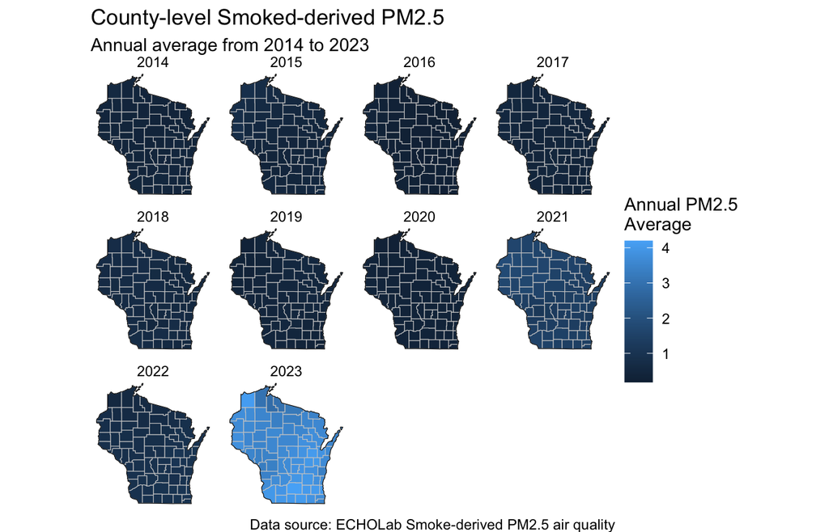

```r
# Use Case #1 - Annual average, county level ----
# -- Map to confirm ----
# average
  ggplot() +
  # data layer on botom
    geom_sf(data = county_pop_data,
            color = "gray80",
            aes(fill = annual_pm25_average)) +
  # labels
    labs(title = "County-level Smoked-derived PM2.5",
         subtitle = "Annual average from 2014 to 2023",
         caption = "Data source: ECHOLab Smoke-derived PM2.5 air quality",
         fill = "Annual PM2.5\nAverage") +
  # state border layer on top
    geom_sf(data = sf_wi,
            color = "black",
            fill = NA) +
  # separate map for each value in the county_data_pop$year column
    facet_wrap(~year) +
  # general aestetic design for figure
    theme_void()
```

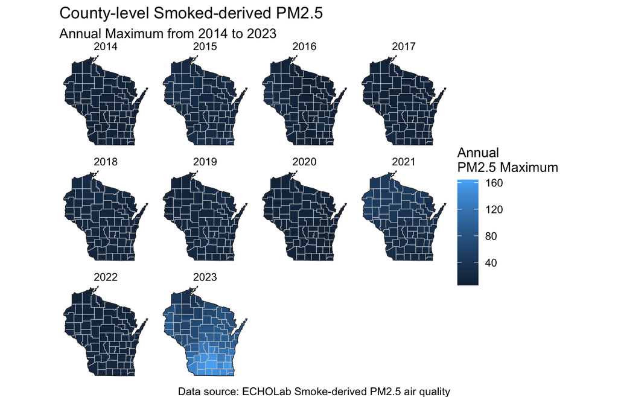

```r
# max
  ggplot() +
    # data layer on botom
    geom_sf(data = county_pop_data,
            color = "gray80",
            aes(fill = annual_pm25_max)) +
    # labels
    labs(title = "County-level Smoked-derived PM2.5",
         subtitle = "Annual Maximum from 2014 to 2023",
         caption = "Data source: ECHOLab Smoke-derived PM2.5 air quality",
         fill = "Annual\nPM2.5 Maximum") +
    # state border layer on top
    geom_sf(data = sf_wi,
            color = "black",
            fill = NA) +
    # separate map for each value in the county_data_pop$year column
    facet_wrap(~year) +
    # general aestetic design for figure
    theme_void()
```

## Use Case #2: Tract-level Seasonal Average PM2.5

This example is similar to the first. We use the tract/date tabular data to compute a seasonal rather than annual average, merge it with the ACS population time series data, and make a few plots. Also, since we are using tract geography, we will reduce to just a few counties in the Southeast corner of the state, which includes the Milwaukee metropolitan area.

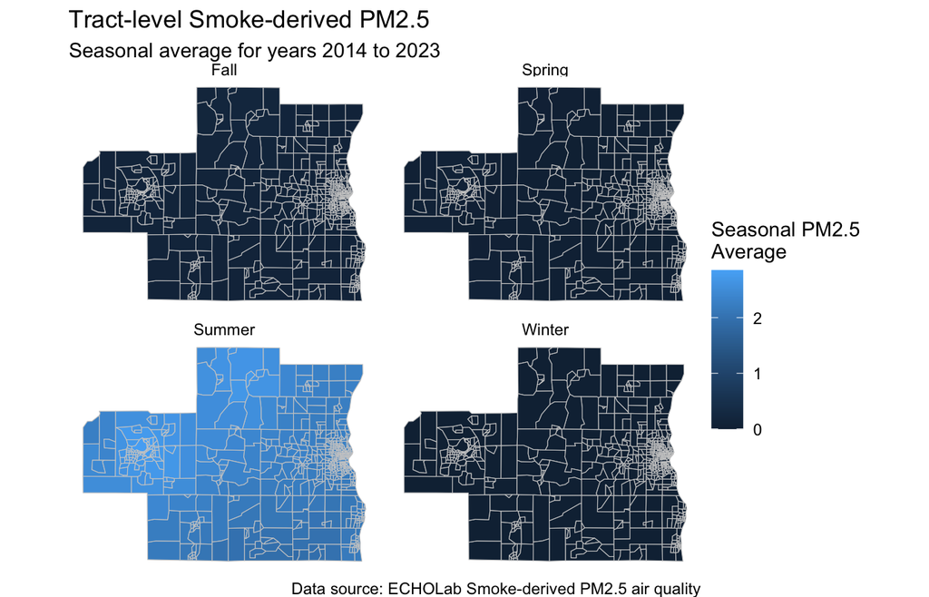

```r
# Use Case #2: Seasonal average, tract level ----
# -- Data Wrangling ----
# generate helper variables
  smoke_tract <- smoke_tract |>
    arrange(GEOID, date) |>
    mutate(year = year(date),
           prior_30 = (date - 30),
           prior_7 = (date - 7),
           window_30day = interval(start = prior_30, end = date),
           window_7day = interval(start = prior_7, end = date))

# make seasonal average
  spring <- (3:5)
  summer <- (6:8)
  fall <- (9:11)
  winter1 <- (12)
  winter2 <- (1:2)

  tract_seasonal_average <- smoke_tract |>
    mutate(month = month(date),
           season = case_when(month %in% spring ~ "Spring",
                              month %in% summer ~ "Summer",
                              month %in% fall ~ "Fall",
                              month %in% winter1 ~ "Winter",
                              month %in% winter2 ~ "Winter"))

  tract_seasonal_average <- tract_seasonal_average |>
    group_by(GEOID, year, season) |>
      arrange(date) |>
      mutate(seasonal_pm25_average = mean(smokePM_pred, na.rm = TRUE),
             seasonal_pm25_max = max(smokePM_pred, na.rm = TRUE)) |>
    ungroup()

# reduce to 1 row per year/season
  tract_seasonal_average <- tract_seasonal_average |>
    dplyr::select(GEOID, year, season, seasonal_pm25_average, seasonal_pm25_max) |>
    distinct()

# stack ACS timeseries data
  tract_pop_data <- bind_rows(acs_tract)

# merge to tract by year and GEOID
  tract_pop_data <- left_join(tract_pop_data, tract_seasonal_average, by = c("GEOID", "year"))

# -- Make data spatial ----
# right_join master county shapefile
  tract_pop_data <- right_join(sf_tract_2010, tract_pop_data, by = "GEOID")

# -- Map to confirm ----
# reduce to fewer counties and a single year, for plotting
  tract_pop_sample <- tract_pop_data |>
    filter(county_fips.x %in% cbg_filter) |>
    filter(year == 2018)

# average
  ggplot() +
    # data layer on botom
    geom_sf(data = tract_pop_sample,
            color = "gray80",
            aes(fill = seasonal_pm25_average)) +
    # labels
    labs(title = "Tract-level Smoke-derived PM2.5",
         subtitle = "Seasonal average for years 2014 to 2023",
         caption = "Data source: ECHOLab Smoke-derived PM2.5 air quality",
         fill = "Seasonal PM2.5\nAverage") +
    # separate map for each value in the county_data_pop$year column
    facet_wrap(~season) +
    # general aestetic design for figure
    theme_void()
```

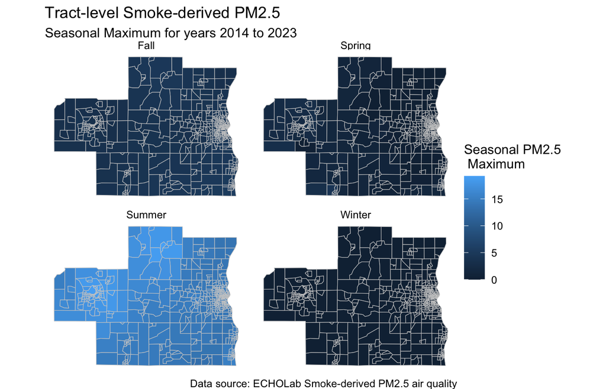

```r
# max
  ggplot() +
    # data layer on botom
    geom_sf(data = tract_pop_sample,
            color = "gray80",
            aes(fill = seasonal_pm25_max)) +
    # labels
    labs(title = "Tract-level Smoke-derived PM2.5",
         subtitle = "Seasonal Maximum for years 2014 to 2023",
         caption = "Data source: ECHOLab Smoke-derived PM2.5 air quality",
         fill = "Seasonal PM2.5\n Maximum") +
    # separate map for each value in the county_data_pop$year column
    facet_wrap(~season) +
    # general aestetic design for figure
    theme_void()
```

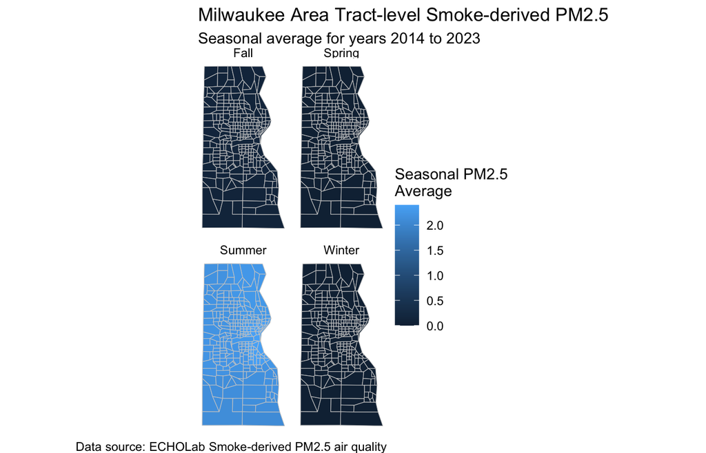

```r
# -- Inspect urban spaces ----
  mke_counties <- c("55079")

  tract_mke <- tract_pop_sample |>
    filter(county_fips.x %in% mke_counties)

# average in Milwaukee county
  ggplot() +
    # data layer on botom
    geom_sf(data = tract_mke,
            color = "gray80",
            aes(fill = seasonal_pm25_average)) +
    # labels
    labs(title = "Milwaukee Area Tract-level Smoke-derived PM2.5",
         subtitle = "Seasonal average for years 2014 to 2023",
         caption = "Data source: ECHOLab Smoke-derived PM2.5 air quality",
         fill = "Seasonal PM2.5\nAverage") +
    # separate map for each value in the county_data_pop$year column
    facet_wrap(~season) +
    # general aestetic design for figure
    theme_void()
```

```r
# clean environment
rm(tract_seasonal_average, tract_pop_sample, tract_mke)
```

## Use Case #3: Individual-level Running Averages and Exposure

Use cases #3 and #4 will test the limits of gridded, vector-based data. While vector-based are exceptional for population level data - which is typically aggregated to administrative boundaries - it may not be at the geographic specificity needed for individual-level survey data. The first consideration is what spatial scale do you want to capture the measure of environmental exposure? This should be driven by your research question and any empirical or theoretical basis for how you are conceptualizing the environmental exposure. In multiple steps, we will demonstrate data integration at the county, tract, and 10km scales.

### Prepare running averages in the smoke data

Before we do any data integration, let’s prepare our smoke data by generating variables for running averages and mins/max at all geographic levels. We are using the `slider` package to compute running averages on tabular data. Note that the data must be grouped by the geographic identifier (grid_id for the 10km gridded data, and GEOID for county and tract data) and then arranged by the date variable. The `slider::slide_dbl()` function then calculates some summary statistic for each date based on the values of the previous dates, as determined by the parameters. This function can take some time to complete.

Recall that when we imported the ECHOLab smoke data, we included a December 2013. That way, we could gather the running average for the first 30 days of 2014.

```r
# -- 10km/tract/county running averages/min/max ----
# NOTE: slider package for running averages
# 10km grid
  smoke_10km <- smoke_10km |>
    group_by(grid_id_10km) |>
    arrange(date) |>
    mutate(mean_30day = slide_dbl(smokePM_pred, mean,
                                  .before = 30, .after = 0, .complete = TRUE),
           max_30day = slide_dbl(smokePM_pred, max,
                                 .before = 30, .after = 0, .complete = TRUE),
           min_30day = slide_dbl(smokePM_pred, min,
                                 .before = 30, .after = 0, .complete = TRUE),
           mean_7day = slide_dbl(smokePM_pred, mean,
                                 .before = 7, .after = 0, .complete = TRUE),
           max_7day = slide_dbl(smokePM_pred, mean,
                                .before = 7, .after = 0, .complete = TRUE),
           min_7day = slide_dbl(smokePM_pred, mean,
                                .before = 7, .after = 0, .complete = TRUE)) |>
    ungroup() |>
    arrange(grid_id_10km, date)

# tract
  smoke_tract <- smoke_tract |>
    group_by(GEOID) |>
    arrange(date) |>
    mutate(mean_30day = slide_dbl(smokePM_pred, mean,
                                  .before = 30, .after = 0, .complete = TRUE),
           max_30day = slide_dbl(smokePM_pred, max,
                                 .before = 30, .after = 0, .complete = TRUE),
           min_30day = slide_dbl(smokePM_pred, min,
                                 .before = 30, .after = 0, .complete = TRUE),
           mean_7day = slide_dbl(smokePM_pred, mean,
                                 .before = 7, .after = 0, .complete = TRUE),
           max_7day = slide_dbl(smokePM_pred, mean,
                                .before = 7, .after = 0, .complete = TRUE),
           min_7day = slide_dbl(smokePM_pred, mean,
                                .before = 7, .after = 0, .complete = TRUE)) |>
    ungroup() |>
    arrange(GEOID, date)

# county
smoke_county <- smoke_county |>
  group_by(GEOID) |>
  arrange(date) |>
  mutate(mean_30day = slide_dbl(smokePM_pred, mean,
                                .before = 30, .after = 0, .complete = TRUE),
         max_30day = slide_dbl(smokePM_pred, max,
                               .before = 30, .after = 0, .complete = TRUE),
         min_30day = slide_dbl(smokePM_pred, min,
                               .before = 30, .after = 0, .complete = TRUE),
         mean_7day = slide_dbl(smokePM_pred, mean,
                               .before = 7, .after = 0, .complete = TRUE),
         max_7day = slide_dbl(smokePM_pred, mean,
                              .before = 7, .after = 0, .complete = TRUE),
         min_7day = slide_dbl(smokePM_pred, mean,
                              .before = 7, .after = 0, .complete = TRUE)) |>
  ungroup() |>
  arrange(GEOID, date)
```

### County/tract smoke data -> survey data

Since the tabular survey data is geocoded with tract and county FIPS identifiers, and the ECHOLab smoke data has tract and county FIPs identifiers, we can perform a simple tabular `left_join()` to integrate county and tract-level PM2.5 for each respondent’s survey date.

```r
# -- Tabular join smoke data by county-level GEOIDs and survey date ----
# rename columns to match survey_points dataframe
  temp <- smoke_county |>
    rename(county_fips = GEOID,
           survey_date = date)

  survey_county <- left_join(survey_df,
                             temp,
                             by = c("county_fips", "survey_date"))

# -- Tabular join smoke data by tract-level GEOIDs and survey date----
# rename columns to match survey_points dataframe
  temp <- smoke_tract |>
    rename(tract_fips = GEOID,
           survey_date = date)

  survey_tract <- left_join(survey_df,
                            temp,
                            by = c("tract_fips", "survey_date"))
```

### 10km smoke data -> survey data

The county and tract level smoke data was straightforward to integrate with the survey data because both contained tabular geographic identifiers. However, the surevey data does not have a tabular idnetifier for the 10km grid polygon. So, we will have to use spatial data operations to assign the correct 10km grid ID to each survey record.

The survey data contains variables for the precise lat/long of the respondent’s home address (its okay! its tpy data!). You can use this geographic information to integrate 10km gridded PM2.5 using spatial data operations following the steps below:

1. Convert the tabular survey data to a `sf` R object using `st_as_sf()`.
2. As a sanity check, map the survey data points by layering them over the 10km grid to visualize where each respondent’s lat/long fall into one of the 10km grid polygons.
3. Use `st_join()` to do the same “layering” process behind the scenes. `st_join()` takes each respondent’s point geometry, places it into a 10km polygon, and extracts the corresponding 10km grid polygon’s attribute data into the survey data. This will assign the 10km grid identification number to every respondent, which we will then use in a tabular merge to integrate the smoke data.
4. Finally, perform a `left_join()` based on the 10km grid ID variable and survey date variable to integrate the tabular smoke_10km data into the survey data.

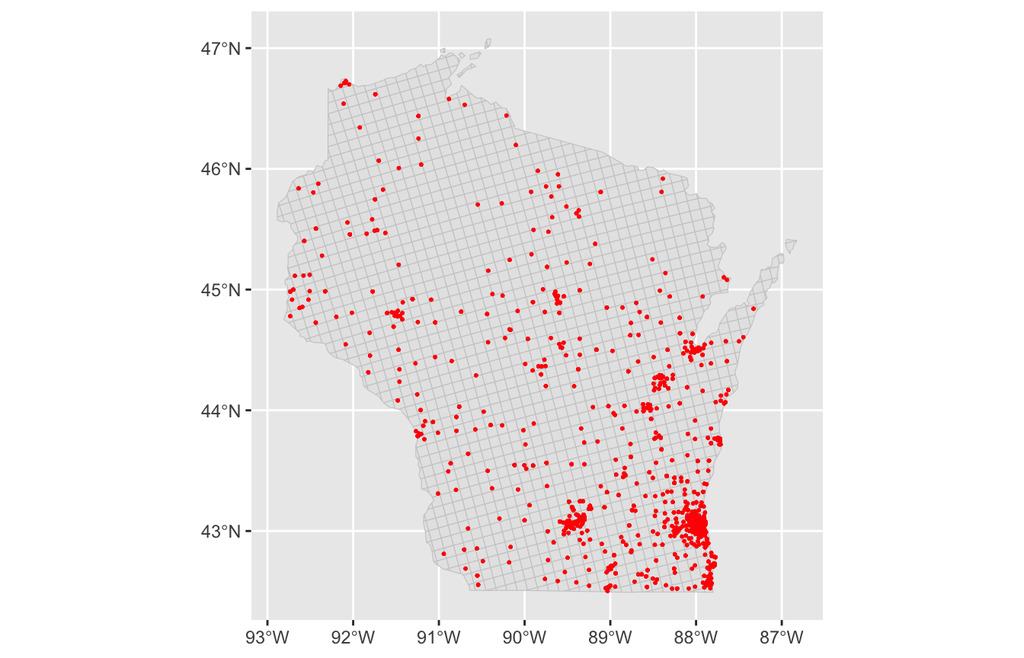

```r
# -- Make Survey Data Spatial using lat/long variables ----
# convert to sf_points object
  survey_points <- st_as_sf(survey_df,
                            coords = c("longitude", "latitude"),
                            crs = master_crs)

# -- map survey_points over 10km_grid to visualize st_join() procedure ----
  ggplot() +
    geom_sf(data = sf_wi_10km,
            color = "gray80") +
    geom_sf(data = survey_points,
            color = "red",
            size = 0.30)
```

```r
# -- Place point in a 10km grid and extract grid polygon attributes ----
# spatial join attributes from grid geometry into survey data rows
  survey_points <- st_join(survey_points, sf_wi_10km) |>
    dplyr::select(-COORDY) |>
    dplyr::select(-COORDX)

# -- Tabular join smoke data based on survey date and 10km grid id ----
# rename columns to match survey_points dataframe
  temp <- smoke_10km |>
    rename(ID = grid_id_10km,
           survey_date = date)

# left_join smoke data to survey data
  survey_10km <- left_join(survey_points,
                           temp,
                           by = c("ID", "survey_date"))

# clean up environment
  rm(temp, survey_points)
```

Now, we have basic smoke data for each respondent, matching the date they took each survey wave. We integrated data at three different levels: the county, tract, and 10km grid. The data is stored in three separate data frames, one for each level of geography (`survey_10km`, `survey_county`, and `survey_tract`).

Investigate the data.frames using the `View(survey_10km)` function typed directly into the console.

## Use Case #4: Spatial Buffer and Spatial Interpolation

Use case # 3 assigned county, tract, and 10km grid smoke data to each survey respondent record. The assignment was based on the precise lat/long of each respondents home address. Let’s map a selection of these points over county and 10km grids to visualize the which county data and 10km grid data are assigned to each respondent.

```r
# convert to sf_points object
  survey_points <- st_as_sf(survey_df,
                            coords = c("longitude", "latitude"),
                            crs = master_crs)

# see extent of survey_buffer object for mapping purposes
  st_bbox(survey_points)
```

```
##      xmin      ymin      xmax      ymax
## -92.73418  42.50278 -87.32943  46.72767
```

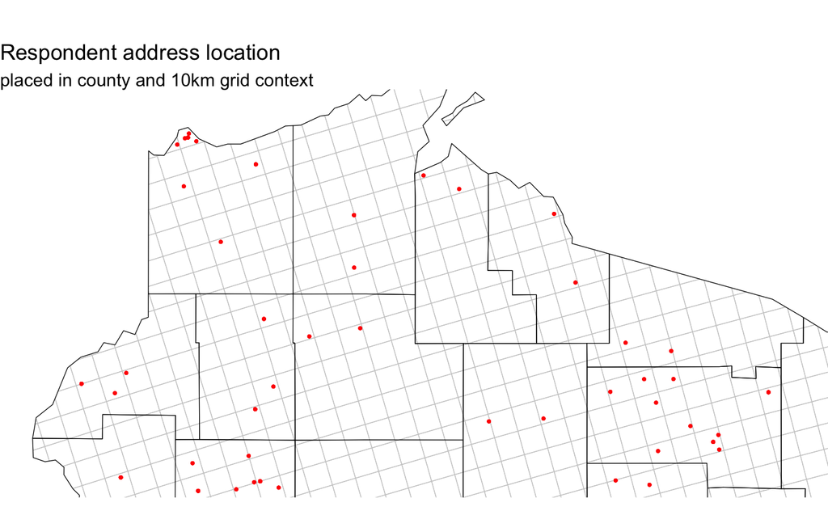

```r
# map for sanity check
  ggplot() +
    # grid layer
    geom_sf(data = sf_wi_10km,
            color = "gray80",
            fill = NA) +
    # county boundary layer
    geom_sf(data = sf_county_2010,
            color = "black",
            fill = NA) +
    # point layer
    geom_sf(data = survey_points,
            color = "red",
            size = 0.5) +
    # restrict plot to just lat/longs in northwest, based of of st_bbox() output
    coord_sf(xlim = c(-92.86145, -89),
             ylim = c(45.5, 46.81861)) +
    # labels
    labs(title = "Respondent address location",
         subtitle = "placed in county and 10km grid context") +
    theme_void()
```

Note that some points fall along county borders. Perhaps the county average is not an appropriate measure of smoke exposure. What if a respondent lives in the very corner of a large county, and does most of their daily living across the county border?

Or, what if they live at the very corner of a 10km grid? Is the smoke exposure value for that single 10km grid the best measure for that respondent? In both cases, wouldn’t we want some information about the grids or counties nearby?

To address this, we can generate distance buffers around point geometries and use spatial data operations to gather the smoke data from the areas within the buffers. This is opposed to relying on nominally assigned aggregated data, like counties or 10km polygons. This process is called spatial interpolation. It is useful when standard geographies are not quite appropriate for your exposure measure.

Let’s perform a spatial interpolation step by step, and through the process highlight some examples for why this is a useful procedure.

### Generate buffer polygons around point data

First, we will convert the point data to a custom distance buffer polygon. Examine the shapefile’s CRS to see which units the projection uses.

```r
# check for units in survey_points crs
  st_crs(survey_points)
```

```
## Coordinate Reference System:
##   User input: NAD83
##   wkt:
## GEOGCRS["NAD83",
##     DATUM["North American Datum 1983",
##         ELLIPSOID["GRS 1980",6378137,298.257222101,
##             LENGTHUNIT["metre",1]]],
##     PRIMEM["Greenwich",0,
##         ANGLEUNIT["degree",0.0174532925199433]],
##     CS[ellipsoidal,2],
##         AXIS["latitude",north,
##             ORDER[1],
##             ANGLEUNIT["degree",0.0174532925199433]],
##         AXIS["longitude",east,
##             ORDER[2],
##             ANGLEUNIT["degree",0.0174532925199433]],
##     ID["EPSG",4269]]
```

In our case, the CRS uses meters (LENGTHUNIT[“metre”,1]). Let’s generate a buffer of 20km diameter around each point, and map them over the 10km grid and the county boundaries.

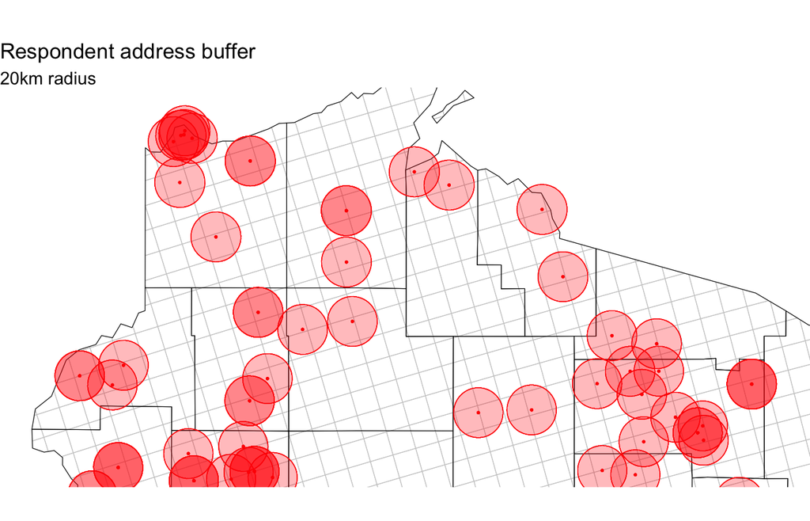

```r
# -- Make buffer polygon ----
# 10km radus, 20km diameter
  survey_buffer <- st_buffer(survey_points, dist = 10000)

# map for sanity check
  ggplot() +
  # grid layer
    geom_sf(data = sf_wi_10km,
            color = "gray80",
            fill = NA) +
  # county boundary layer
    geom_sf(data = sf_county_2010,
            color = "black",
            fill = NA) +
  # buffer layer
    geom_sf(data = survey_buffer,
            color = "red",
            fill = "red",
            alpha = 0.1) +
  # point layer
    geom_sf(data = survey_points,
            color = "red",
            size = 0.3) +
  # zoom to just a few counties in northwest
    coord_sf(xlim = c(-92.86145, -89),
             ylim = c(45.5, 46.81861)) +
  # labels
    labs(title = "Respondent address buffer",
         subtitle = "20km radius") +
    theme_void()
```

### Interpolate smoke data for each buffer

We will use `st_interpolate_aw()` to calculate smoke values based on the 10km grids that fall within the buffer polygon, *NOT* based just on the single 10km grid that the lat/long falls within. `st_interpolate_aw()` performs and area-weighted interpolation of underlying polygon data. This means that the area of each underlying polygon that you are extracting data from serves as the weight when when calculating the average of the underlying polygon data. A grid that is only 1% covered by the 20km buffer contributes an appropriately sized share to the average.

Because we need to repeat this procedure for many different dates, we will perform the interpolation in a `for` loop, executing the `st_interpolate_aw()` day by day. This process will take a few minutes becasue we are inefficiently performing many spatial interpolation procedures over and over. This procedure will produce accurate results, but showcases the limits of vector based data integration procedures over many cases, variables, or with timeseries data.

Let’s define the for loop parameters:

1. Define an empty list object to store interpolated data from each loop iteration.
2. Define a list of the dates in the survey data that we need to access in the smoke_10km data.frame.
3. Define the smoke_10km variables we want to extract

```r
# -- For Loop parameters ----
# empty list object
  survey_list <- list()

# list of dates in survey data
  survey_dates <- survey_df |>
    dplyr::select(survey_date) |>
    group_by(survey_date) |>
    slice(1) |>
    ungroup()

  survey_dates <- c(survey_dates$survey_date)

# for testing, use below survey_dates with few dates
# replace 3 with some number to sample smaller N of dates
  # survey_dates <- sample(survey_dates$survey_date, 3, replace = FALSE)

# list of variables to merge
  smoke_vars <- c("smokePM_pred",
                  "mean_30day",
                  "mean_7day")
```

Then, run the loop. The loop performs the following processes for each date in the survey data:

1. Reduce the survey data and the smoke_10km data to a single date.
2. Use `right_join()` with tabular `smoke_10km` and shapefile `sf_wi_10km` to spatialize the smoke data.
3. Perform a spatial interpolation on the smoke variables.
4. Append the interpolated averages back to the tabular survey_buffer data.
5. Save that date’s data to a list.

```r
# -- For loop to perform spatial interopolation ----
# for every date in the survey...
  for (d_i in survey_dates) {
  # make temporary naming object
    date_name <- c(d_i)

  # filter the survey_buffer data to a single date, d_i
    survey_temp <- survey_buffer |>
      filter(survey_date == d_i)

  # skip to next date if no records exist in survey_temp
  # (this is a sanity check. Our survey_dates list of dates is defined
  # from the actual data source, so there should not be iteration that
  # does not have data.)
    if (nrow(survey_temp) == 0) next

  # filter smoke_10km data to single date, d_i
    smoke_temp <- smoke_10km |>
      filter(date == d_i) |>
      rename(ID = grid_id_10km)

  # make smoke_temp spatial
    smoke_temp <- right_join(sf_wi_10km, smoke_temp, by = "ID") |>
      dplyr::select(smoke_vars)

  # use_st_interpolate_aw() function
    temp <- st_interpolate_aw(smoke_temp, survey_temp, extensive = FALSE)

  # append interpolated columns to survey_temp
    survey_temp$pm25_w_avg <- temp$smokePM_pred
    survey_temp$mean_30day_w_avg <- temp$mean_30day
    survey_temp$mean_7day_w_avg <- temp$mean_7day

  # append to list
    survey_list[[paste0(d_i,"weighted_avg")]] <- survey_temp

  # clean up
    rm(survey_temp,
       temp,
       smoke_temp)

  } # close for loop

  gc()
```

```
##             used   (Mb) gc trigger   (Mb) limit (Mb)  max used   (Mb)
## Ncells   5988001  319.8   16032904  856.3         NA  39142828 2090.5
## Vcells 200859294 1532.5  561827265 4286.5      24576 560143573 4273.6
```

Finally, let’s stack the list objects for each individual date back into a standard dataframe. Use `View()` to examine the `survey_buffer` data and newly created `pm25_w_avg`, `mean_30day_w_avg`, and `mean_7day_w_avg` variables.

```r
# stack interpolated dataframe
survey_buffer <- bind_rows(survey_list)
```

## Compare different levels of data integration

Let’s make a final data set, `survey_final`, that has the county level, tract level, 10km grid level, and interpolated buffer level measures of smoke data.

```r
# -- Compare Point-level differences ----
# ---- Combine all smokePM_pred values into one df ----

# make our final survey data set
  survey_final <- as.data.frame(survey_buffer)

# append 10km_grid level to final
  temp <- as.data.frame(survey_10km) |>
    dplyr::select(respondent_ID, ID, survey_wave, smoke_vars) |>
    rename(grid_id = ID,
           pm25_grid = smokePM_pred,
           mean_30day_grid = mean_30day,
           mean_7day_grid = mean_7day)

  survey_final <- left_join(survey_final, temp, by = c("respondent_ID", "survey_wave"))

# traappend tract level to final
  temp <- as.data.frame(survey_tract) |>
    dplyr::select(respondent_ID, survey_wave, smoke_vars) |>
    rename(pm25_tract = smokePM_pred,
           mean_30day_tract = mean_30day,
           mean_7day_tract = mean_7day)

  survey_final <- left_join(survey_final, temp, by = c("respondent_ID", "survey_wave"))

# append county level to final
  temp <- as.data.frame(survey_county) |>
    dplyr::select(respondent_ID, survey_wave, smoke_vars) |>
    rename(pm25_county = smokePM_pred,
           mean_30day_county = mean_30day,
           mean_7day_county = mean_7day)

  survey_final <- left_join(survey_final, temp, by = c("respondent_ID", "survey_wave"))
```

Now, we have a single data frame where, for each respondent, we have measures of smoke exposure captured at county, tract, 10km grid, and the 10km weighted average based on the 20km point buffer. Perform any comparisons or robustness checks using these variables the same way you might in any tabular data set. Additionally, because the data is spatial, you can account for spatial relationships in your analyses using spatial regression techniques.

# Concluding Remarks -

The above case studies demonstrate typical ways to integrate gridded, vector-based high-frequency spatio-temporal data with population and survey data. They demonstrate the process using both standardized geographic boundaries and identifiers (county and tract FIPS) as well as non-standard geographic identifiers (10km grids).

Gridded environmental data is an accessible, low-demand way to integrate environmental data into social science, population, and health research. The above workflow may vary from data set to data set, but is largely applicable to vector-based gridded data.

Finally, note that vector-based gridded data is not typically generated at the finest level of spatial and temporal specificity. If you require environmental data that is specific to the hour, specific to a small area (meters, not miles), or expansive over very wide ranges and time frames, then raster-based environmental data may be necessary. Processing raster-based data requires additional R packages, more computing power including parallel processing, and data storage solutions. See the resources in Part 1: Raster Data, and the below resources. Many entries have guidance on processing raster-based environmental data.

# Resources -

[**Geospatial Health Data: Modeling and Visualization with R-INLA and Shiny**](https://www.paulamoraga.com/book-geospatial/index.html) by Paula Moraga - Advanced geospatial and spatio-temporal processing and analysis using INLA.

[**R Graphics Codebook**](https://r-graphics.org/) - Comprehensive guide on tweaking any and all aspects of figures in R.

[**UW-Madison Social Science Computing Cooperative**](https://sscc.wisc.edu/sscc/pubs/r_programming/) - a range of R programming resources from the Social Science Computing Cooperative at the University of Wisconsin-Madison.

[**YaRrr! The Pirate’s Guide to R**](https://nathanieldphillips-yarrr.share.connect.posit.cloud/) by Nathaniel D. Phillips - learn R from the ground up! The pirate theme is a bonus…

[**R for Data Science (2e)**](https://r4ds.hadley.nz/) by Hadley Wickham - comprehensive guide to data wrangling in R using the tidyverse coding conventions.

[**Introduction to R - tidyverse**](https://bansell-wehi-tidyr-course-book.share.connect.posit.cloud/) by Brendan R. E. Ansell - comprehensive guide to data wrangling, plotting, and programming in R using the tidyverse coding conventions.